# ANCOVA test for debate (engajamento no debate)

Geiser C. Challco geiser@alumni.usp.br

- Descriptive Statistics of Initial Data
- Checking of Assumptions
  - Assumption: Normality distribution of data
  - Assumption: Homogeneity of data distribution
- Computation of ANCOVA test and Pairwise Comparison
  - ANCOVA tests for one factor
  - ANCOVA tests for two factors
  - ANCOVA tests for grupo=“WordGen”
  - Pairwise comparisons for one factor
    - factor: **grupo**
    - factor: **genero**
    - factor: **idade**
    - factor: **zona.participante**
    - factor: **escola**
    - factor: **zona.escola**
  - Pairwise comparisons for two factors
    - factores: **grupo:genero**
    - factores: **grupo:idade**
    - factores: **grupo:zona.participante**
    - factores: **grupo:escola**
    - factores: **grupo:zona.escola**
  - Pairwise comparisons for grupo=“Experimental”
    - factores: **grupo=“Experimental”:monitor**
    - factores: **grupo=“Experimental”:monitor.genero**
    - factores: **grupo=“Experimental”:monitor.area**
    - factores: **grupo=“Experimental”:monitor.formacao**
    - factores: **grupo=“Experimental”:monitor.experiencia**

**NOTE**

- Teste ANCOVA para determinar se houve diferenças significativas em referência ao engajamento no debate (medido como estado de fluxo).
- ANCOVA test to determine whether there were significant differences in reference to engagement in debate (measured as flow state).

# Descriptive Statistics of Initial Data

| grupo | genero | idade | zona.participante | escola | zona.escola | variable | n | mean | median | min | max | sd | se | ci | iqr |
| --- | --- | --- | --- | --- | --- | --- | --- | --- | --- | --- | --- | --- | --- | --- | --- |
| Controle | F |  |  |  |  | fss.debate | 60 | 3.533 | 3.556 | 2.444 | 4.333 | 0.492 | 0.063 | 0.127 | 0.580 |
| Controle | M |  |  |  |  | fss.debate | 62 | 3.322 | 3.333 | 2.111 | 4.222 | 0.501 | 0.064 | 0.127 | 0.667 |
| WordGen | F |  |  |  |  | fss.debate | 52 | 3.683 | 3.667 | 2.111 | 4.750 | 0.529 | 0.073 | 0.147 | 0.694 |
| WordGen | M |  |  |  |  | fss.debate | 63 | 3.442 | 3.444 | 2.111 | 5.000 | 0.573 | 0.072 | 0.144 | 0.667 |
| Controle | F |  |  |  |  | dfs.debate | 60 | 3.481 | 3.556 | 2.333 | 4.556 | 0.542 | 0.070 | 0.140 | 0.795 |
| Controle | M |  |  |  |  | dfs.debate | 62 | 3.444 | 3.444 | 2.000 | 4.556 | 0.586 | 0.074 | 0.149 | 0.750 |
| WordGen | F |  |  |  |  | dfs.debate | 52 | 3.560 | 3.667 | 2.222 | 4.667 | 0.520 | 0.072 | 0.145 | 0.472 |
| WordGen | M |  |  |  |  | dfs.debate | 63 | 3.356 | 3.250 | 2.375 | 4.556 | 0.535 | 0.067 | 0.135 | 0.889 |
| Controle |  | 10y |  |  |  | fss.debate | 24 | 3.440 | 3.444 | 2.111 | 4.333 | 0.629 | 0.128 | 0.266 | 1.139 |
| Controle |  | 11y |  |  |  | fss.debate | 65 | 3.424 | 3.444 | 2.111 | 4.333 | 0.479 | 0.059 | 0.119 | 0.639 |
| Controle |  | 12y |  |  |  | fss.debate | 17 | 3.515 | 3.444 | 2.778 | 4.333 | 0.456 | 0.111 | 0.235 | 0.667 |
| Controle |  | 13y |  |  |  | fss.debate | 7 | 3.349 | 3.222 | 2.889 | 3.889 | 0.360 | 0.136 | 0.333 | 0.500 |
| Controle |  | 14y |  |  |  | fss.debate | 1 | 3.667 | 3.667 | 3.667 | 3.667 |  |  |  | 0.000 |
| Controle |  | 15y |  |  |  | fss.debate | 1 | 2.222 | 2.222 | 2.222 | 2.222 |  |  |  | 0.000 |
| Controle |  | 16y |  |  |  | fss.debate | 1 | 3.111 | 3.111 | 3.111 | 3.111 |  |  |  | 0.000 |
| Controle |  |  |  |  |  | fss.debate | 6 | 3.434 | 3.444 | 2.714 | 4.111 | 0.495 | 0.202 | 0.519 | 0.556 |
| WordGen |  | 10y |  |  |  | fss.debate | 22 | 3.470 | 3.444 | 2.556 | 4.444 | 0.487 | 0.104 | 0.216 | 0.500 |
| WordGen |  | 11y |  |  |  | fss.debate | 70 | 3.601 | 3.556 | 2.111 | 5.000 | 0.592 | 0.071 | 0.141 | 0.618 |
| WordGen |  | 12y |  |  |  | fss.debate | 14 | 3.603 | 3.667 | 2.667 | 4.444 | 0.483 | 0.129 | 0.279 | 0.528 |
| WordGen |  | 13y |  |  |  | fss.debate | 6 | 3.123 | 3.111 | 2.625 | 3.778 | 0.385 | 0.157 | 0.404 | 0.250 |
| WordGen |  | 14y |  |  |  | fss.debate | 1 | 4.667 | 4.667 | 4.667 | 4.667 |  |  |  | 0.000 |
| WordGen |  |  |  |  |  | fss.debate | 2 | 3.056 | 3.056 | 2.889 | 3.222 | 0.236 | 0.167 | 2.118 | 0.167 |
| Controle |  | 10y |  |  |  | dfs.debate | 24 | 3.513 | 3.556 | 2.444 | 4.556 | 0.538 | 0.110 | 0.227 | 0.611 |
| Controle |  | 11y |  |  |  | dfs.debate | 65 | 3.485 | 3.556 | 2.000 | 4.556 | 0.565 | 0.070 | 0.140 | 0.667 |
| Controle |  | 12y |  |  |  | dfs.debate | 17 | 3.533 | 3.444 | 2.778 | 4.500 | 0.533 | 0.129 | 0.274 | 0.667 |
| Controle |  | 13y |  |  |  | dfs.debate | 7 | 3.450 | 3.444 | 2.556 | 4.375 | 0.581 | 0.220 | 0.537 | 0.556 |
| Controle |  | 14y |  |  |  | dfs.debate | 1 | 2.556 | 2.556 | 2.556 | 2.556 |  |  |  | 0.000 |
| Controle |  | 15y |  |  |  | dfs.debate | 1 | 2.111 | 2.111 | 2.111 | 2.111 |  |  |  | 0.000 |
| Controle |  | 16y |  |  |  | dfs.debate | 1 | 3.556 | 3.556 | 3.556 | 3.556 |  |  |  | 0.000 |
| Controle |  |  |  |  |  | dfs.debate | 6 | 3.185 | 3.056 | 2.667 | 4.000 | 0.515 | 0.210 | 0.540 | 0.667 |
| WordGen |  | 10y |  |  |  | dfs.debate | 22 | 3.343 | 3.500 | 2.333 | 4.444 | 0.519 | 0.111 | 0.230 | 0.722 |
| WordGen |  | 11y |  |  |  | dfs.debate | 70 | 3.550 | 3.611 | 2.222 | 4.667 | 0.548 | 0.065 | 0.131 | 0.667 |
| WordGen |  | 12y |  |  |  | dfs.debate | 14 | 3.310 | 3.222 | 2.778 | 4.111 | 0.436 | 0.117 | 0.252 | 0.750 |
| WordGen |  | 13y |  |  |  | dfs.debate | 6 | 3.157 | 3.167 | 2.500 | 3.778 | 0.475 | 0.194 | 0.498 | 0.611 |
| WordGen |  | 14y |  |  |  | dfs.debate | 1 | 2.750 | 2.750 | 2.750 | 2.750 |  |  |  | 0.000 |
| WordGen |  |  |  |  |  | dfs.debate | 2 | 3.222 | 3.222 | 2.778 | 3.667 | 0.629 | 0.444 | 5.647 | 0.444 |
| Controle |  |  | Urbana |  |  | fss.debate | 51 | 3.443 | 3.375 | 2.111 | 4.333 | 0.525 | 0.073 | 0.148 | 0.604 |
| Controle |  |  | Rural |  |  | fss.debate | 43 | 3.364 | 3.444 | 2.111 | 4.333 | 0.523 | 0.080 | 0.161 | 0.667 |
| Controle |  |  |  |  |  | fss.debate | 28 | 3.488 | 3.646 | 2.556 | 4.222 | 0.446 | 0.084 | 0.173 | 0.583 |
| WordGen |  |  | Urbana |  |  | fss.debate | 43 | 3.588 | 3.556 | 2.625 | 4.778 | 0.504 | 0.077 | 0.155 | 0.611 |
| WordGen |  |  | Rural |  |  | fss.debate | 47 | 3.456 | 3.444 | 2.111 | 4.750 | 0.572 | 0.083 | 0.168 | 0.715 |
| WordGen |  |  |  |  |  | fss.debate | 25 | 3.667 | 3.667 | 2.111 | 5.000 | 0.635 | 0.127 | 0.262 | 0.778 |
| Controle |  |  | Urbana |  |  | dfs.debate | 51 | 3.365 | 3.444 | 2.000 | 4.500 | 0.628 | 0.088 | 0.177 | 0.833 |
| Controle |  |  | Rural |  |  | dfs.debate | 43 | 3.532 | 3.556 | 2.444 | 4.556 | 0.526 | 0.080 | 0.162 | 0.889 |
| Controle |  |  |  |  |  | dfs.debate | 28 | 3.531 | 3.500 | 2.778 | 4.556 | 0.476 | 0.090 | 0.185 | 0.556 |
| WordGen |  |  | Urbana |  |  | dfs.debate | 43 | 3.393 | 3.444 | 2.222 | 4.667 | 0.578 | 0.088 | 0.178 | 0.833 |
| WordGen |  |  | Rural |  |  | dfs.debate | 47 | 3.441 | 3.444 | 2.556 | 4.556 | 0.541 | 0.079 | 0.159 | 0.722 |
| WordGen |  |  |  |  |  | dfs.debate | 25 | 3.557 | 3.667 | 2.500 | 4.222 | 0.443 | 0.089 | 0.183 | 0.500 |
| Controle |  |  |  | E1 |  | fss.debate | 12 | 3.361 | 3.333 | 2.222 | 4.333 | 0.596 | 0.172 | 0.379 | 0.778 |
| Controle |  |  |  | E2 |  | fss.debate | 22 | 3.363 | 3.333 | 2.111 | 4.333 | 0.610 | 0.130 | 0.271 | 0.851 |
| Controle |  |  |  | E3 |  | fss.debate | 15 | 3.421 | 3.444 | 2.778 | 4.333 | 0.417 | 0.108 | 0.231 | 0.389 |
| Controle |  |  |  | E4 |  | fss.debate | 15 | 3.393 | 3.222 | 2.778 | 4.333 | 0.482 | 0.125 | 0.267 | 0.778 |
| Controle |  |  |  | E5 |  | fss.debate | 47 | 3.474 | 3.444 | 2.111 | 4.333 | 0.510 | 0.074 | 0.150 | 0.604 |
| Controle |  |  |  | E6 |  | fss.debate | 11 | 3.465 | 3.667 | 2.556 | 3.778 | 0.358 | 0.108 | 0.240 | 0.333 |
| WordGen |  |  |  | E1 |  | fss.debate | 10 | 3.779 | 3.611 | 2.500 | 4.667 | 0.645 | 0.204 | 0.461 | 0.608 |
| WordGen |  |  |  | E2 |  | fss.debate | 24 | 3.448 | 3.444 | 2.625 | 4.222 | 0.432 | 0.088 | 0.182 | 0.556 |
| WordGen |  |  |  | E3 |  | fss.debate | 15 | 3.231 | 3.333 | 2.111 | 4.222 | 0.576 | 0.149 | 0.319 | 0.611 |
| WordGen |  |  |  | E4 |  | fss.debate | 9 | 3.775 | 3.556 | 3.111 | 4.750 | 0.616 | 0.205 | 0.473 | 0.778 |
| WordGen |  |  |  | E5 |  | fss.debate | 46 | 3.555 | 3.667 | 2.111 | 5.000 | 0.562 | 0.083 | 0.167 | 0.556 |
| WordGen |  |  |  | E6 |  | fss.debate | 11 | 3.808 | 3.889 | 3.111 | 4.444 | 0.531 | 0.160 | 0.357 | 0.889 |
| Controle |  |  |  | E1 |  | dfs.debate | 12 | 3.139 | 3.333 | 2.111 | 4.111 | 0.545 | 0.157 | 0.346 | 0.611 |
| Controle |  |  |  | E2 |  | dfs.debate | 22 | 3.505 | 3.556 | 2.375 | 4.444 | 0.476 | 0.102 | 0.211 | 0.556 |
| Controle |  |  |  | E3 |  | dfs.debate | 15 | 3.643 | 3.556 | 2.778 | 4.556 | 0.555 | 0.143 | 0.308 | 0.778 |
| Controle |  |  |  | E4 |  | dfs.debate | 15 | 3.403 | 3.556 | 2.111 | 4.375 | 0.638 | 0.165 | 0.353 | 0.556 |
| Controle |  |  |  | E5 |  | dfs.debate | 47 | 3.476 | 3.556 | 2.000 | 4.556 | 0.611 | 0.089 | 0.179 | 0.944 |
| Controle |  |  |  | E6 |  | dfs.debate | 11 | 3.505 | 3.444 | 2.778 | 4.111 | 0.349 | 0.105 | 0.235 | 0.278 |
| WordGen |  |  |  | E1 |  | dfs.debate | 10 | 3.179 | 3.222 | 2.375 | 3.778 | 0.417 | 0.132 | 0.298 | 0.500 |
| WordGen |  |  |  | E2 |  | dfs.debate | 24 | 3.498 | 3.500 | 2.500 | 4.667 | 0.545 | 0.111 | 0.230 | 0.694 |
| WordGen |  |  |  | E3 |  | dfs.debate | 15 | 3.496 | 3.778 | 2.556 | 4.556 | 0.696 | 0.180 | 0.386 | 1.000 |
| WordGen |  |  |  | E4 |  | dfs.debate | 9 | 3.537 | 3.444 | 3.000 | 4.500 | 0.441 | 0.147 | 0.339 | 0.444 |
| WordGen |  |  |  | E5 |  | dfs.debate | 46 | 3.414 | 3.556 | 2.222 | 4.222 | 0.548 | 0.081 | 0.163 | 0.778 |
| WordGen |  |  |  | E6 |  | dfs.debate | 11 | 3.591 | 3.667 | 2.889 | 4.111 | 0.355 | 0.107 | 0.239 | 0.361 |
| Controle |  |  |  |  | Urbana | fss.debate | 81 | 3.427 | 3.444 | 2.111 | 4.333 | 0.547 | 0.061 | 0.121 | 0.667 |
| Controle |  |  |  |  | Rural | fss.debate | 41 | 3.422 | 3.444 | 2.556 | 4.333 | 0.418 | 0.065 | 0.132 | 0.556 |
| WordGen |  |  |  |  | Urbana | fss.debate | 80 | 3.551 | 3.556 | 2.111 | 5.000 | 0.540 | 0.060 | 0.120 | 0.580 |
| WordGen |  |  |  |  | Rural | fss.debate | 35 | 3.552 | 3.444 | 2.111 | 4.750 | 0.623 | 0.105 | 0.214 | 0.889 |
| Controle |  |  |  |  | Urbana | dfs.debate | 81 | 3.434 | 3.444 | 2.000 | 4.556 | 0.575 | 0.064 | 0.127 | 0.889 |
| Controle |  |  |  |  | Rural | dfs.debate | 41 | 3.518 | 3.556 | 2.111 | 4.556 | 0.540 | 0.084 | 0.171 | 0.667 |
| WordGen |  |  |  |  | Urbana | dfs.debate | 80 | 3.410 | 3.444 | 2.222 | 4.667 | 0.535 | 0.060 | 0.119 | 0.778 |
| WordGen |  |  |  |  | Rural | dfs.debate | 35 | 3.537 | 3.667 | 2.556 | 4.556 | 0.533 | 0.090 | 0.183 | 0.694 |

# Checking of Assumptions

## Assumption: Normality distribution of data

| var | n | skewness | kurtosis | symmetry | statistic | method | p | p.signif | normality |
| --- | --- | --- | --- | --- | --- | --- | --- | --- | --- |
| fss.debate | 237 | 0.0581079 | 0.0517534 | YES | 0.3618463 | D’Agostino | 0.8344995 | ns | - |
| fss.debate | 229 | -0.0718357 | 0.1996869 | YES | 1.0044923 | D’Agostino | 0.6051698 | ns | - |
| fss.debate | 184 | 0.1918401 | 0.0408362 | YES | 1.4236289 | D’Agostino | 0.4907530 | ns | QQ |
| fss.debate | 237 | 0.0134525 | -0.0490396 | YES | 0.0283578 | D’Agostino | 0.9859211 | ns | - |
| fss.debate | 237 | 0.0377817 | 0.0307007 | YES | 0.2225611 | D’Agostino | 0.8946877 | ns | - |

## Assumption: Homogeneity of data distribution

| var | method | formula | n | DFn.df1 | DFd.df2 | statistic | p | p.signif |
| --- | --- | --- | --- | --- | --- | --- | --- | --- |
| fss.debate | Levene’s test | `.res`~`grupo`*`genero` | 237 | 3 | 233 | 1.1514008 | 0.3291336 | ns |
| fss.debate | Anova’s slopes | `.res`~`grupo`*`genero` | 237 | 3 | 229 | 0.6360000 | 0.5930000 | ns |
| fss.debate | Levene’s test | `.res`~`grupo`*`idade` | 229 | 11 | 217 | 1.3290062 | 0.2096949 | ns |
| fss.debate | Anova’s slopes | `.res`~`grupo`*`idade` | 229 | 7 | 209 | 0.7620000 | 0.6200000 | ns |
| fss.debate | Levene’s test | `.res`~`grupo`*`zona.participante` | 184 | 3 | 180 | 0.8155691 | 0.4867925 | ns |
| fss.debate | Anova’s slopes | `.res`~`grupo`*`zona.participante` | 184 | 3 | 176 | 0.8260000 | 0.4810000 | ns |
| fss.debate | Levene’s test | `.res`~`grupo`*`escola` | 237 | 11 | 225 | 0.6158700 | 0.8144816 | ns |
| fss.debate | Anova’s slopes | `.res`~`grupo`*`escola` | 237 | 11 | 213 | 1.5620000 | 0.1120000 | ns |
| fss.debate | Levene’s test | `.res`~`grupo`*`zona.escola` | 237 | 3 | 233 | 0.7717322 | 0.5108562 | ns |
| fss.debate | Anova’s slopes | `.res`~`grupo`*`zona.escola` | 237 | 3 | 229 | 2.4560000 | 0.0640000 | ns |

# Computation of ANCOVA test and Pairwise Comparison

## ANCOVA tests for one factor

|  | Effect | DFn | DFd | SSn | SSd | F | p | ges | p<.05 |
| --- | --- | --- | --- | --- | --- | --- | --- | --- | --- |
| 1 | dfs.debate | 1 | 234 | 9.200 | 57.937 | 37.158 | <0.001 | 0.137 | * |
| 2 | grupo | 1 | 234 | 1.008 | 57.937 | 4.071 | 0.045 | 0.017 | * |
| 4 | genero | 1 | 234 | 1.881 | 57.064 | 7.715 | 0.006 | 0.032 | * |
| 6 | idade | 6 | 221 | 3.347 | 54.000 | 2.283 | 0.037 | 0.058 | * |
| 8 | zona.participante | 1 | 181 | 0.791 | 45.457 | 3.148 | 0.078 | 0.017 |  |
| 10 | escola | 5 | 230 | 2.782 | 56.163 | 2.279 | 0.048 | 0.047 | * |
| 12 | zona.escola | 1 | 234 | 0.102 | 58.843 | 0.404 | 0.525 | 0.002 |  |

## ANCOVA tests for two factors

|  | Effect | DFn | DFd | SSn | SSd | F | p | ges | p<.05 |
| --- | --- | --- | --- | --- | --- | --- | --- | --- | --- |
| 1 | dfs.debate | 1 | 232 | 8.198 | 55.935 | 34.002 | <0.001 | 0.128 | * |
| 4 | grupo:genero | 1 | 232 | 0.010 | 55.935 | 0.042 | 0.837 | 0.000 |  |
| 8 | grupo:idade | 4 | 216 | 0.565 | 52.412 | 0.583 | 0.676 | 0.011 |  |
| 12 | grupo:zona.participante | 1 | 179 | 0.002 | 44.696 | 0.008 | 0.927 | 0.000 |  |
| 16 | grupo:escola | 5 | 224 | 1.368 | 53.655 | 1.142 | 0.339 | 0.025 |  |
| 20 | grupo:zona.escola | 1 | 232 | 0.001 | 57.854 | 0.005 | 0.946 | 0.000 |  |

## ANCOVA tests for grupo=“WordGen”

|  | Effect | DFn | DFd | SSn | SSd | F | p | ges | p<.05 |
| --- | --- | --- | --- | --- | --- | --- | --- | --- | --- |
| 1 | dfs.debate | 1 | 100 | 5.006 | 25.056 | 19.977 | <0.001 | 0.167 | * |
| 2 | monitor | 9 | 100 | 5.738 | 25.056 | 2.544 | 0.011 | 0.186 | * |
| 4 | monitor.genero | 1 | 108 | 1.282 | 29.513 | 4.690 | 0.033 | 0.042 | * |
| 6 | monitor.area | 8 | 101 | 5.097 | 25.698 | 2.504 | 0.016 | 0.166 | * |
| 8 | monitor.formacao | 2 | 107 | 0.332 | 30.462 | 0.583 | 0.56 | 0.011 |  |
| 10 | monitor.experiencia | 1 | 108 | 0.001 | 30.793 | 0.004 | 0.952 | 0.000 |  |

## Pairwise comparisons for one factor

### factor: **grupo**

| var | grupo | n | M (pre) | SE (pre) | M (unadj) | SE (unadj) | M (adj) | SE (adj) |
| --- | --- | --- | --- | --- | --- | --- | --- | --- |
| fss.debate | Controle | 122 | 3.462 | 0.051 | 3.426 | 0.046 | 3.423 | 0.045 |
| fss.debate | WordGen | 115 | 3.448 | 0.050 | 3.551 | 0.053 | 3.554 | 0.046 |

| .y. | group1 | group2 | estimate | conf.low | conf.high | se | statistic | p | p.adj | p.adj.signif |
| --- | --- | --- | --- | --- | --- | --- | --- | --- | --- | --- |
| fss.debate | Controle | WordGen | -0.131 | -0.258 | -0.003 | 0.065 | -2.018 | 0.045 | 0.045 | * |
| dfs.debate | Controle | WordGen | 0.014 | -0.127 | 0.155 | 0.071 | 0.195 | 0.846 | 0.846 | ns |

| .y. | grupo | group1 | group2 | estimate | conf.low | conf.high | se | statistic | p | p.adj | p.adj.signif |
| --- | --- | --- | --- | --- | --- | --- | --- | --- | --- | --- | --- |
| flow.debate | Controle | pre | pos | 0.036 | -0.100 | 0.173 | 0.069 | 0.524 | 0.60 | 0.60 | ns |
| flow.debate | WordGen | pre | pos | -0.103 | -0.243 | 0.037 | 0.071 | -1.441 | 0.15 | 0.15 | ns |

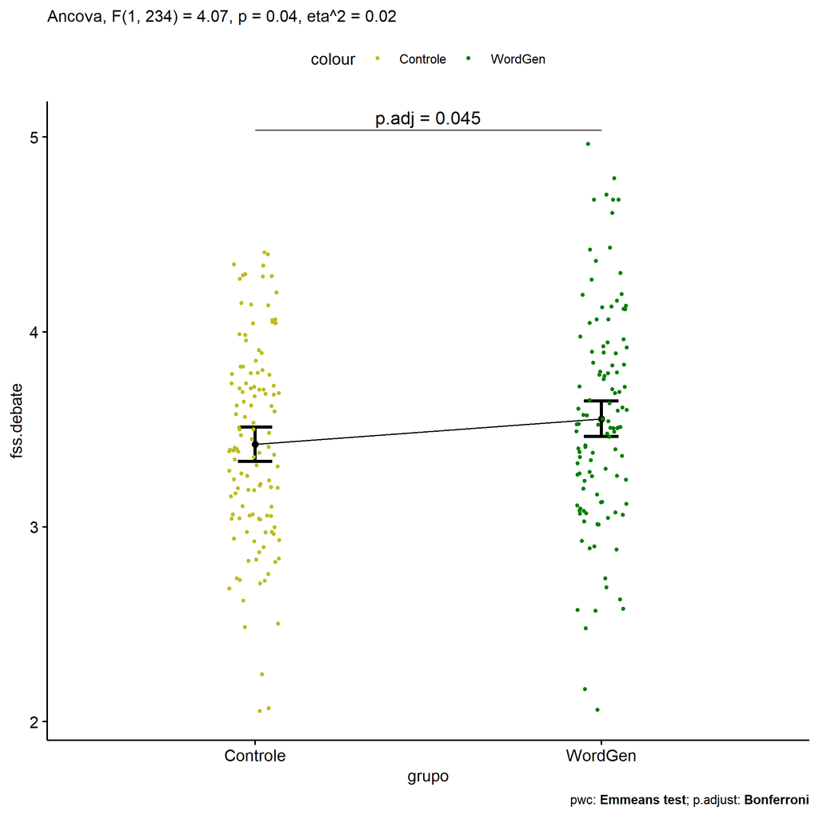

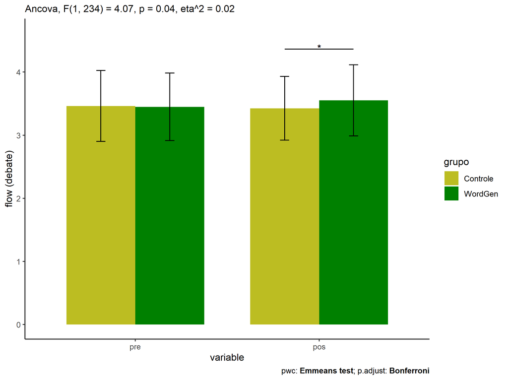

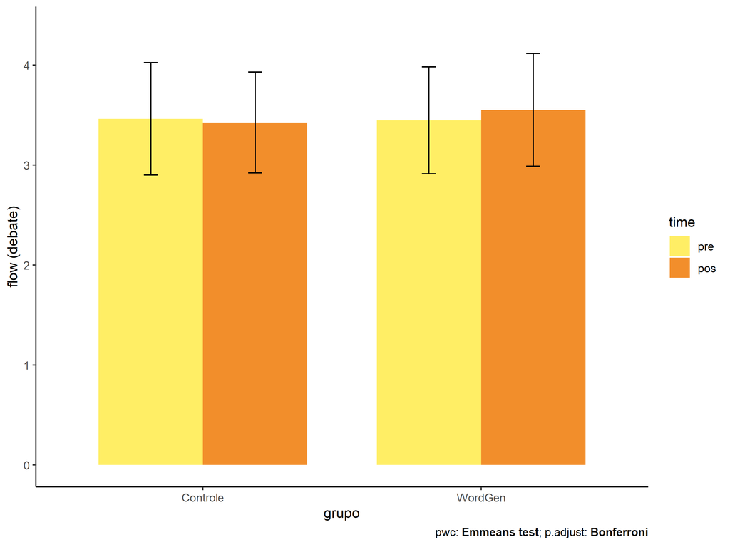

### factor: **genero**

| var | genero | n | M (pre) | SE (pre) | M (unadj) | SE (unadj) | M (adj) | SE (adj) |
| --- | --- | --- | --- | --- | --- | --- | --- | --- |
| fss.debate | F | 112 | 3.518 | 0.05 | 3.603 | 0.048 | 3.581 | 0.047 |
| fss.debate | M | 125 | 3.399 | 0.05 | 3.383 | 0.048 | 3.402 | 0.044 |

| .y. | group1 | group2 | estimate | conf.low | conf.high | se | statistic | p | p.adj | p.adj.signif |
| --- | --- | --- | --- | --- | --- | --- | --- | --- | --- | --- |
| fss.debate | F | M | 0.180 | 0.052 | 0.307 | 0.065 | 2.778 | 0.006 | 0.006 | ** |
| dfs.debate | F | M | 0.118 | -0.022 | 0.258 | 0.071 | 1.664 | 0.097 | 0.097 | ns |

| .y. | genero | group1 | group2 | estimate | conf.low | conf.high | se | statistic | p | p.adj | p.adj.signif |
| --- | --- | --- | --- | --- | --- | --- | --- | --- | --- | --- | --- |
| flow.debate | F | pre | pos | -0.085 | -0.226 | 0.056 | 0.072 | -1.183 | 0.237 | 0.237 | ns |
| flow.debate | M | pre | pos | 0.017 | -0.117 | 0.150 | 0.068 | 0.246 | 0.805 | 0.805 | ns |

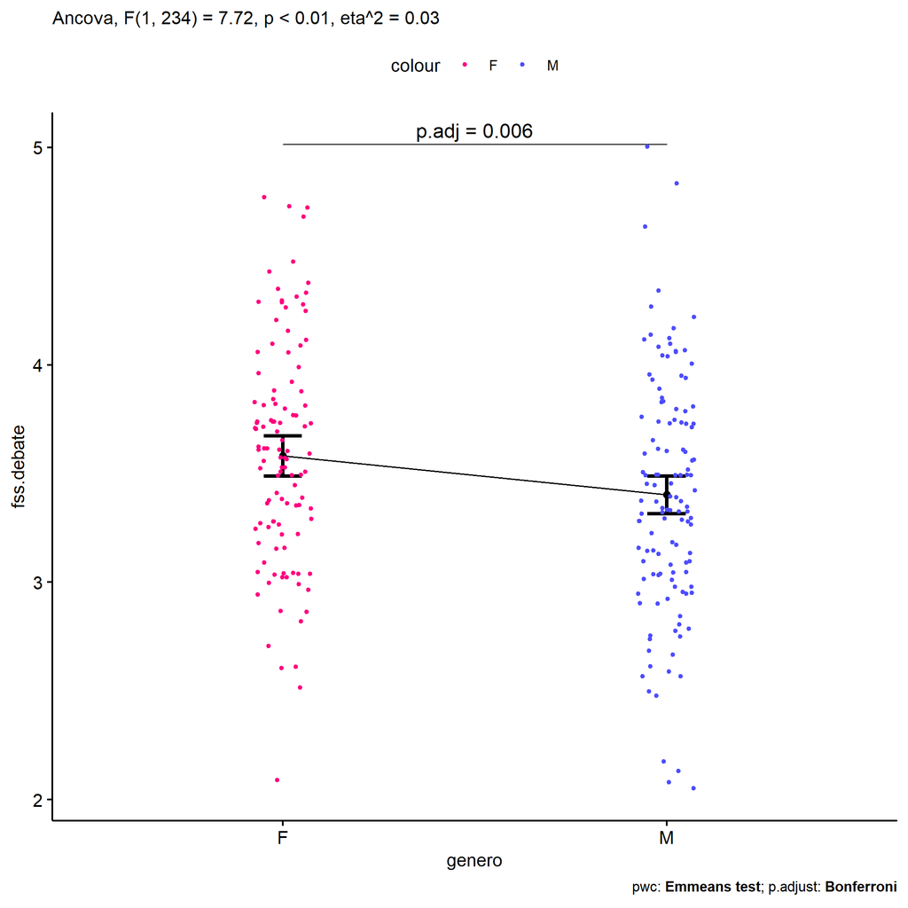

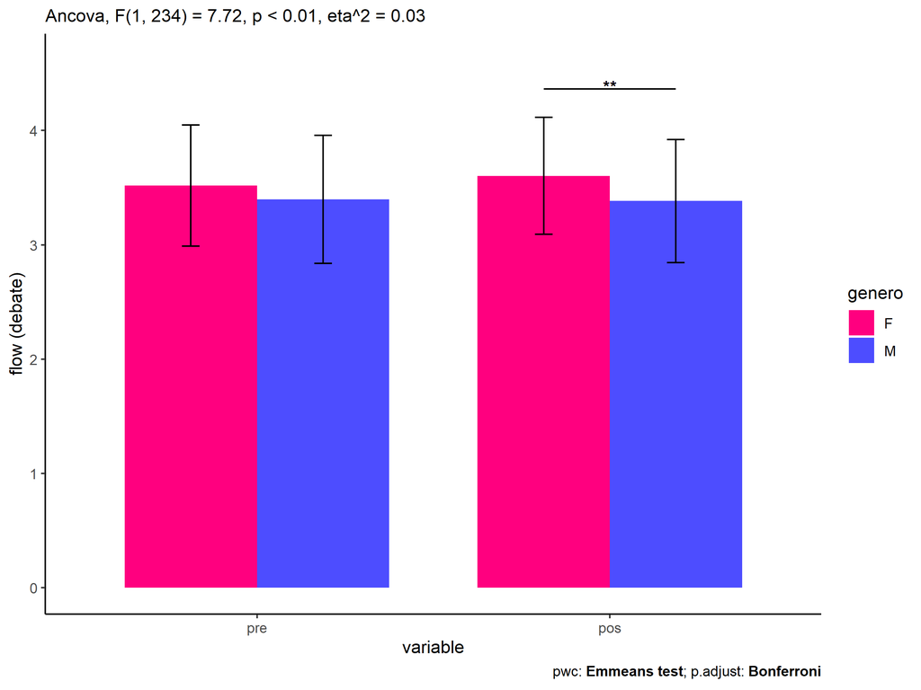

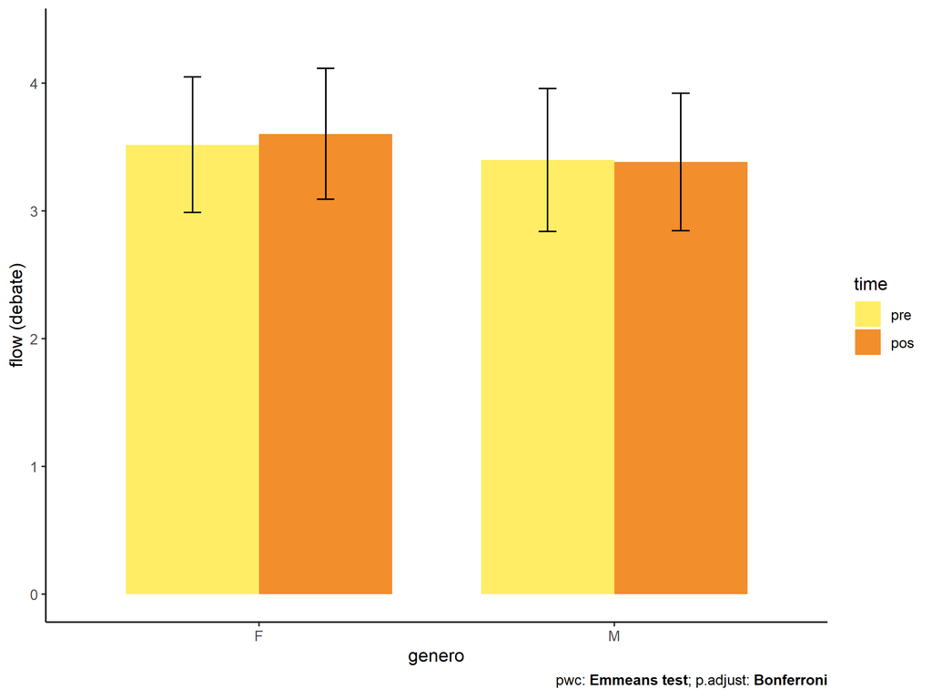

### factor: **idade**

| var | idade | n | M (pre) | SE (pre) | M (unadj) | SE (unadj) | M (adj) | SE (adj) |
| --- | --- | --- | --- | --- | --- | --- | --- | --- |
| fss.debate | 10y | 46 | 3.432 | 0.078 | 3.454 | 0.083 | 3.471 | 0.073 |
| fss.debate | 11y | 135 | 3.519 | 0.048 | 3.516 | 0.047 | 3.501 | 0.043 |
| fss.debate | 12y | 31 | 3.432 | 0.089 | 3.555 | 0.083 | 3.571 | 0.089 |
| fss.debate | 13y | 13 | 3.315 | 0.148 | 3.245 | 0.104 | 3.304 | 0.137 |

| .y. | group1 | group2 | estimate | conf.low | conf.high | se | statistic | p | p.adj | p.adj.signif |
| --- | --- | --- | --- | --- | --- | --- | --- | --- | --- | --- |
| fss.debate | 10y | 11y | -0.030 | -0.196 | 0.136 | 0.084 | -0.354 | 0.723 | 1.000 | ns |
| fss.debate | 10y | 12y | -0.100 | -0.326 | 0.126 | 0.115 | -0.874 | 0.383 | 1.000 | ns |
| fss.debate | 10y | 13y | 0.167 | -0.139 | 0.473 | 0.155 | 1.078 | 0.282 | 1.000 | ns |
| fss.debate | 11y | 12y | -0.070 | -0.264 | 0.124 | 0.098 | -0.714 | 0.476 | 1.000 | ns |
| fss.debate | 11y | 13y | 0.197 | -0.086 | 0.481 | 0.144 | 1.371 | 0.172 | 1.000 | ns |
| fss.debate | 12y | 13y | 0.267 | -0.054 | 0.589 | 0.163 | 1.639 | 0.103 | 0.616 | ns |
| dfs.debate | 10y | 11y | -0.087 | -0.269 | 0.095 | 0.092 | -0.942 | 0.347 | 1.000 | ns |
| dfs.debate | 10y | 12y | 0.000 | -0.248 | 0.248 | 0.126 | -0.001 | 0.999 | 1.000 | ns |
| dfs.debate | 10y | 13y | 0.117 | -0.218 | 0.452 | 0.170 | 0.686 | 0.494 | 1.000 | ns |
| dfs.debate | 11y | 12y | 0.087 | -0.125 | 0.299 | 0.108 | 0.806 | 0.421 | 1.000 | ns |
| dfs.debate | 11y | 13y | 0.204 | -0.106 | 0.513 | 0.157 | 1.296 | 0.196 | 1.000 | ns |
| dfs.debate | 12y | 13y | 0.117 | -0.236 | 0.469 | 0.179 | 0.653 | 0.515 | 1.000 | ns |

| .y. | idade | group1 | group2 | estimate | conf.low | conf.high | se | statistic | p | p.adj | p.adj.signif |
| --- | --- | --- | --- | --- | --- | --- | --- | --- | --- | --- | --- |
| flow.debate | 10y | pre | pos | -0.023 | -0.242 | 0.197 | 0.112 | -0.203 | 0.839 | 0.839 | ns |
| flow.debate | 11y | pre | pos | 0.003 | -0.125 | 0.131 | 0.065 | 0.043 | 0.966 | 0.966 | ns |
| flow.debate | 12y | pre | pos | -0.123 | -0.390 | 0.145 | 0.136 | -0.902 | 0.368 | 0.368 | ns |
| flow.debate | 13y | pre | pos | 0.071 | -0.343 | 0.484 | 0.210 | 0.336 | 0.737 | 0.737 | ns |

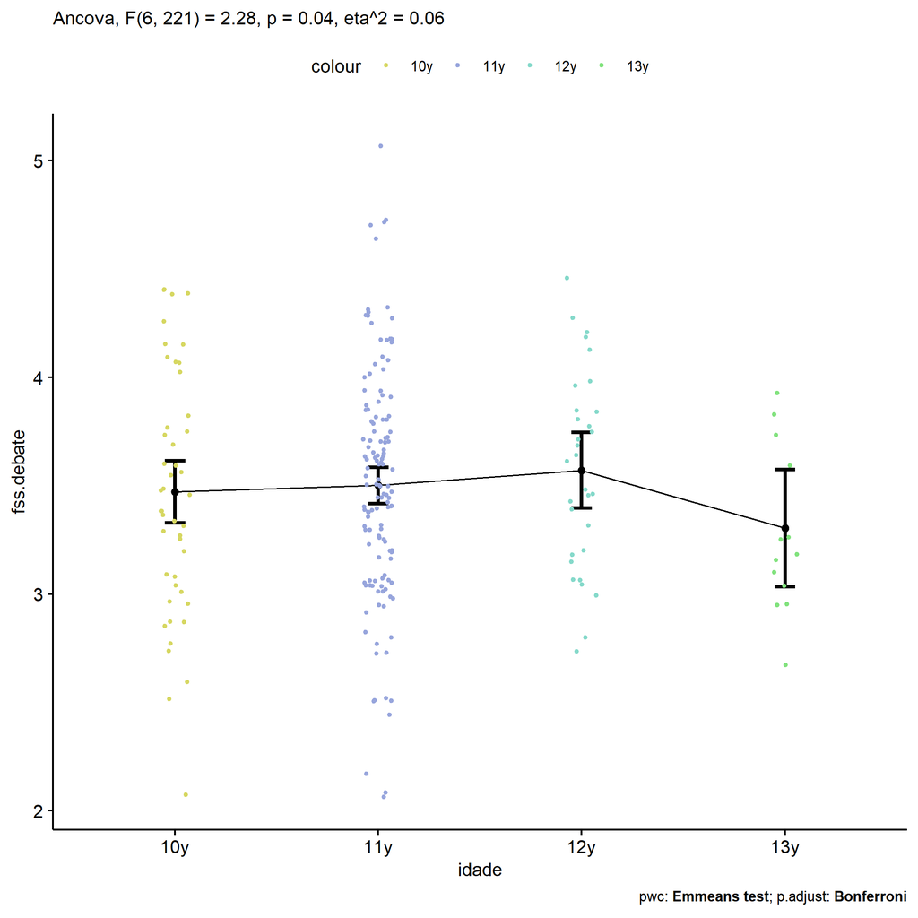

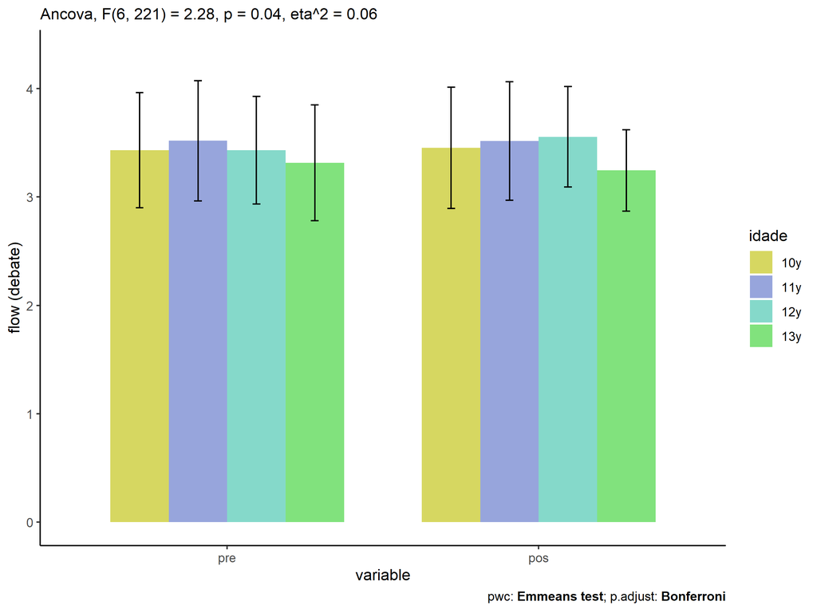

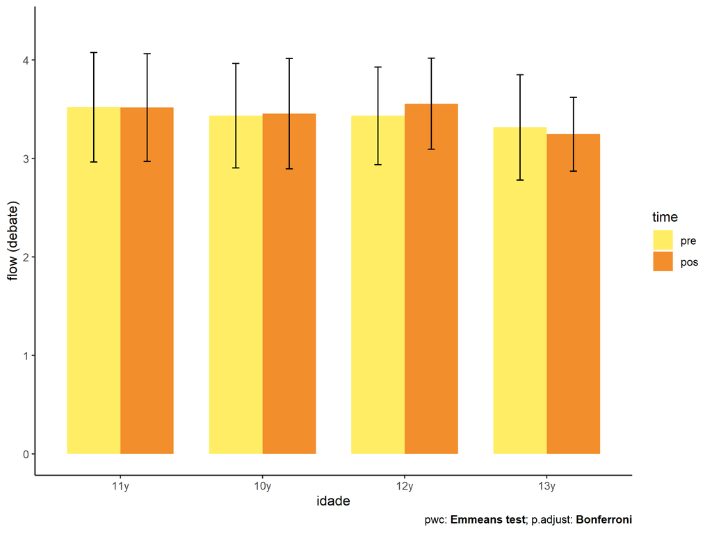

### factor: **zona.participante**

| var | zona.participante | n | M (pre) | SE (pre) | M (unadj) | SE (unadj) | M (adj) | SE (adj) |
| --- | --- | --- | --- | --- | --- | --- | --- | --- |
| fss.debate | Rural | 90 | 3.484 | 0.056 | 3.412 | 0.058 | 3.395 | 0.053 |
| fss.debate | Urbana | 94 | 3.378 | 0.062 | 3.509 | 0.053 | 3.526 | 0.052 |

| .y. | group1 | group2 | estimate | conf.low | conf.high | se | statistic | p | p.adj | p.adj.signif |
| --- | --- | --- | --- | --- | --- | --- | --- | --- | --- | --- |
| fss.debate | Urbana | Rural | 0.132 | -0.015 | 0.278 | 0.074 | 1.774 | 0.078 | 0.078 | ns |
| dfs.debate | Urbana | Rural | -0.106 | -0.272 | 0.059 | 0.084 | -1.267 | 0.207 | 0.207 | ns |

| .y. | zona.participante | group1 | group2 | estimate | conf.low | conf.high | se | statistic | p | p.adj | p.adj.signif |
| --- | --- | --- | --- | --- | --- | --- | --- | --- | --- | --- | --- |
| flow.debate | Urbana | pre | pos | -0.132 | -0.29 | 0.027 | 0.080 | -1.635 | 0.103 | 0.103 | ns |
| flow.debate | Rural | pre | pos | 0.072 | -0.09 | 0.234 | 0.082 | 0.878 | 0.381 | 0.381 | ns |

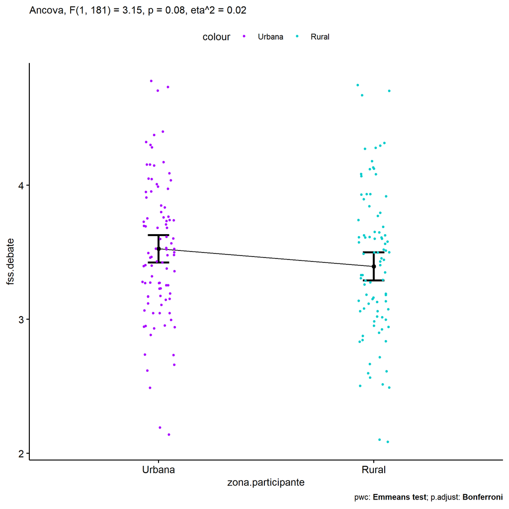

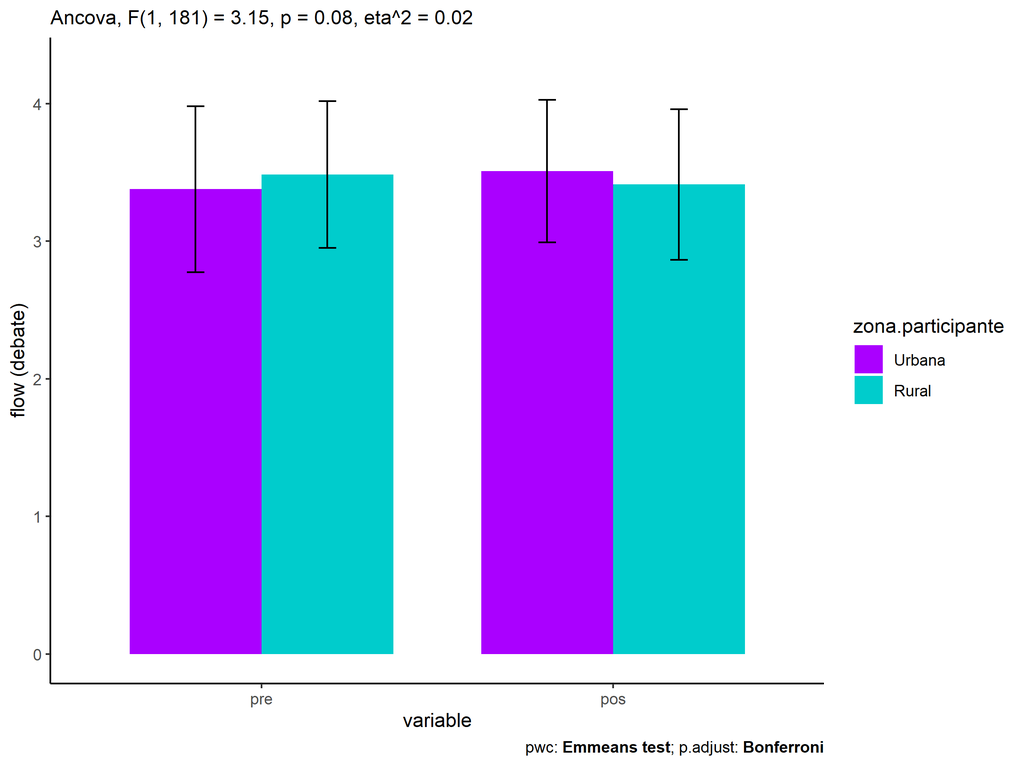

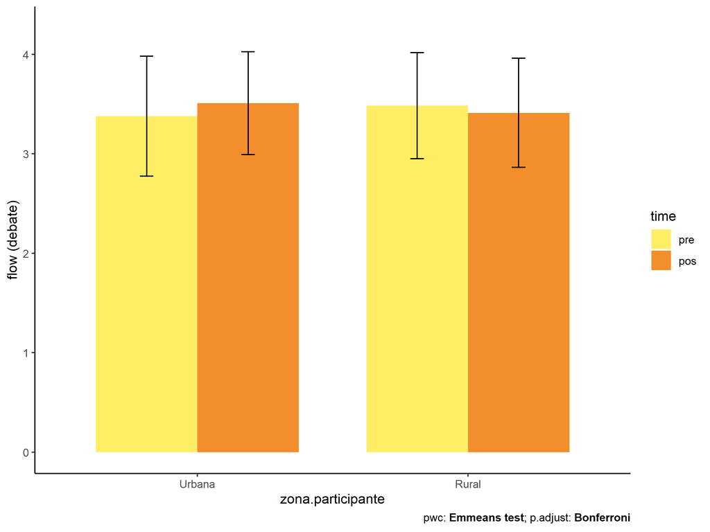

### factor: **escola**

| var | escola | n | M (pre) | SE (pre) | M (unadj) | SE (unadj) | M (adj) | SE (adj) |
| --- | --- | --- | --- | --- | --- | --- | --- | --- |
| fss.debate | E1 | 22 | 3.157 | 0.102 | 3.551 | 0.136 | 3.666 | 0.107 |
| fss.debate | E2 | 46 | 3.501 | 0.075 | 3.408 | 0.077 | 3.390 | 0.073 |
| fss.debate | E3 | 30 | 3.569 | 0.114 | 3.326 | 0.092 | 3.282 | 0.090 |
| fss.debate | E4 | 24 | 3.453 | 0.115 | 3.536 | 0.113 | 3.537 | 0.101 |
| fss.debate | E5 | 93 | 3.445 | 0.060 | 3.514 | 0.055 | 3.518 | 0.051 |
| fss.debate | E6 | 22 | 3.548 | 0.074 | 3.636 | 0.101 | 3.601 | 0.105 |

| .y. | group1 | group2 | estimate | conf.low | conf.high | se | statistic | p | p.adj | p.adj.signif |
| --- | --- | --- | --- | --- | --- | --- | --- | --- | --- | --- |
| fss.debate | E1 | E2 | 0.276 | 0.020 | 0.532 | 0.130 | 2.127 | 0.034 | 0.517 | ns |
| fss.debate | E1 | E3 | 0.384 | 0.106 | 0.662 | 0.141 | 2.725 | 0.007 | 0.104 | ns |
| fss.debate | E1 | E4 | 0.129 | -0.160 | 0.419 | 0.147 | 0.879 | 0.380 | 1.000 | ns |
| fss.debate | E1 | E5 | 0.148 | -0.085 | 0.381 | 0.118 | 1.249 | 0.213 | 1.000 | ns |
| fss.debate | E1 | E6 | 0.065 | -0.232 | 0.362 | 0.151 | 0.433 | 0.666 | 1.000 | ns |
| fss.debate | E2 | E3 | 0.108 | -0.121 | 0.337 | 0.116 | 0.930 | 0.353 | 1.000 | ns |
| fss.debate | E2 | E4 | -0.147 | -0.392 | 0.098 | 0.124 | -1.179 | 0.239 | 1.000 | ns |
| fss.debate | E2 | E5 | -0.128 | -0.304 | 0.048 | 0.089 | -1.437 | 0.152 | 1.000 | ns |
| fss.debate | E2 | E6 | -0.211 | -0.463 | 0.042 | 0.128 | -1.645 | 0.101 | 1.000 | ns |
| fss.debate | E3 | E4 | -0.255 | -0.522 | 0.012 | 0.136 | -1.880 | 0.061 | 0.921 | ns |
| fss.debate | E3 | E5 | -0.236 | -0.441 | -0.031 | 0.104 | -2.270 | 0.024 | 0.362 | ns |
| fss.debate | E3 | E6 | -0.319 | -0.592 | -0.045 | 0.139 | -2.298 | 0.022 | 0.337 | ns |
| fss.debate | E4 | E5 | 0.019 | -0.204 | 0.242 | 0.113 | 0.165 | 0.869 | 1.000 | ns |
| fss.debate | E4 | E6 | -0.064 | -0.352 | 0.224 | 0.146 | -0.438 | 0.662 | 1.000 | ns |
| fss.debate | E5 | E6 | -0.083 | -0.314 | 0.149 | 0.117 | -0.704 | 0.482 | 1.000 | ns |
| dfs.debate | E1 | E2 | -0.344 | -0.622 | -0.066 | 0.141 | -2.440 | 0.015 | 0.231 | ns |
| dfs.debate | E1 | E3 | -0.412 | -0.713 | -0.111 | 0.153 | -2.701 | 0.007 | 0.112 | ns |
| dfs.debate | E1 | E4 | -0.296 | -0.612 | 0.020 | 0.161 | -1.844 | 0.067 | 0.998 | ns |
| dfs.debate | E1 | E5 | -0.288 | -0.542 | -0.034 | 0.129 | -2.232 | 0.027 | 0.398 | ns |
| dfs.debate | E1 | E6 | -0.391 | -0.714 | -0.068 | 0.164 | -2.383 | 0.018 | 0.270 | ns |
| dfs.debate | E2 | E3 | -0.068 | -0.320 | 0.183 | 0.128 | -0.535 | 0.593 | 1.000 | ns |
| dfs.debate | E2 | E4 | 0.048 | -0.222 | 0.318 | 0.137 | 0.351 | 0.726 | 1.000 | ns |
| dfs.debate | E2 | E5 | 0.056 | -0.137 | 0.249 | 0.098 | 0.573 | 0.567 | 1.000 | ns |
| dfs.debate | E2 | E6 | -0.047 | -0.325 | 0.231 | 0.141 | -0.332 | 0.740 | 1.000 | ns |
| dfs.debate | E3 | E4 | 0.116 | -0.177 | 0.410 | 0.149 | 0.781 | 0.436 | 1.000 | ns |
| dfs.debate | E3 | E5 | 0.124 | -0.101 | 0.349 | 0.114 | 1.089 | 0.277 | 1.000 | ns |
| dfs.debate | E3 | E6 | 0.021 | -0.279 | 0.322 | 0.153 | 0.141 | 0.888 | 1.000 | ns |
| dfs.debate | E4 | E5 | 0.008 | -0.237 | 0.253 | 0.125 | 0.065 | 0.948 | 1.000 | ns |
| dfs.debate | E4 | E6 | -0.095 | -0.411 | 0.221 | 0.161 | -0.591 | 0.555 | 1.000 | ns |
| dfs.debate | E5 | E6 | -0.103 | -0.357 | 0.151 | 0.129 | -0.798 | 0.425 | 1.000 | ns |

| .y. | escola | group1 | group2 | estimate | conf.low | conf.high | se | statistic | p | p.adj | p.adj.signif |
| --- | --- | --- | --- | --- | --- | --- | --- | --- | --- | --- | --- |
| flow.debate | E1 | pre | pos | -0.394 | -0.714 | -0.074 | 0.163 | -2.420 | 0.016 | 0.016 | * |
| flow.debate | E2 | pre | pos | 0.094 | -0.128 | 0.315 | 0.113 | 0.832 | 0.406 | 0.406 | ns |
| flow.debate | E3 | pre | pos | 0.244 | -0.030 | 0.517 | 0.139 | 1.747 | 0.081 | 0.081 | ns |
| flow.debate | E4 | pre | pos | -0.083 | -0.389 | 0.223 | 0.156 | -0.531 | 0.596 | 0.596 | ns |
| flow.debate | E5 | pre | pos | -0.069 | -0.225 | 0.086 | 0.079 | -0.872 | 0.383 | 0.383 | ns |
| flow.debate | E6 | pre | pos | -0.088 | -0.408 | 0.231 | 0.163 | -0.543 | 0.587 | 0.587 | ns |

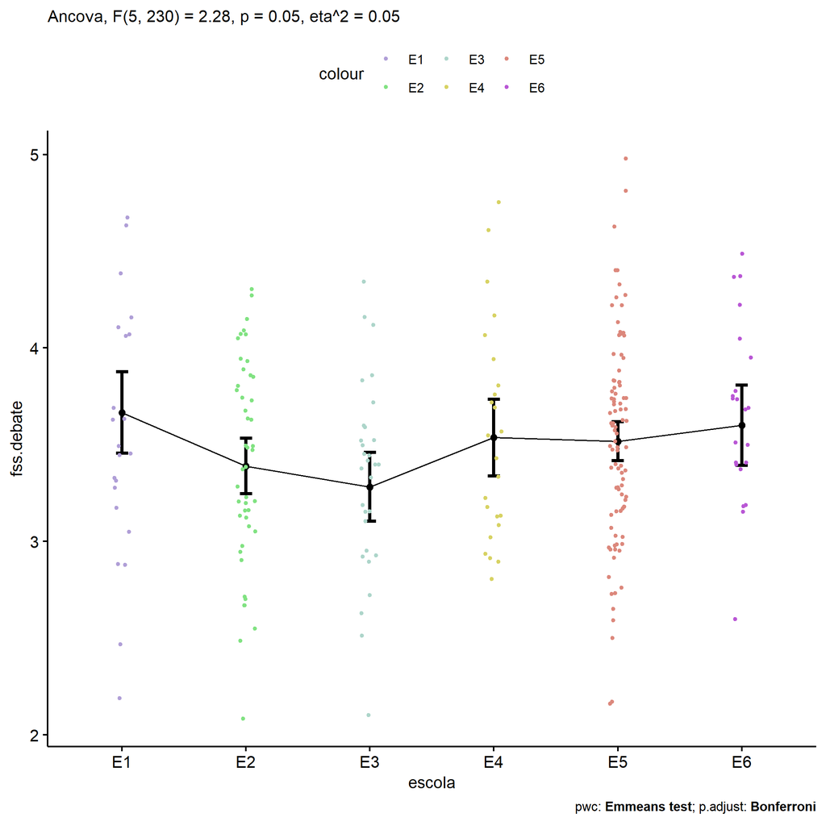

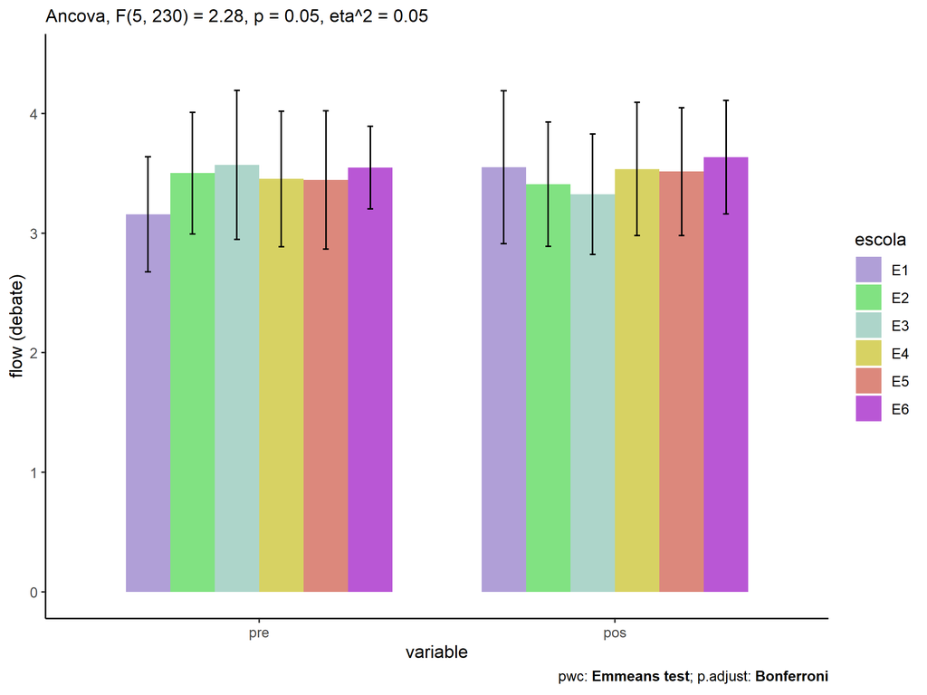

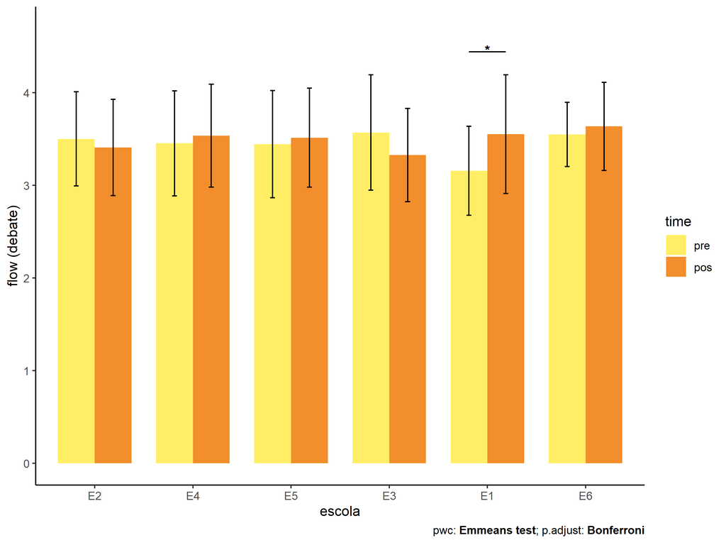

### factor: **zona.escola**

| var | zona.escola | n | M (pre) | SE (pre) | M (unadj) | SE (unadj) | M (adj) | SE (adj) |
| --- | --- | --- | --- | --- | --- | --- | --- | --- |
| fss.debate | Rural | 76 | 3.526 | 0.061 | 3.482 | 0.060 | 3.456 | 0.058 |
| fss.debate | Urbana | 161 | 3.422 | 0.044 | 3.489 | 0.043 | 3.501 | 0.040 |

| .y. | group1 | group2 | estimate | conf.low | conf.high | se | statistic | p | p.adj | p.adj.signif |
| --- | --- | --- | --- | --- | --- | --- | --- | --- | --- | --- |
| fss.debate | Urbana | Rural | 0.045 | -0.093 | 0.183 | 0.070 | 0.636 | 0.525 | 0.525 | ns |
| dfs.debate | Urbana | Rural | -0.105 | -0.255 | 0.045 | 0.076 | -1.375 | 0.170 | 0.170 | ns |

| .y. | zona.escola | group1 | group2 | estimate | conf.low | conf.high | se | statistic | p | p.adj | p.adj.signif |
| --- | --- | --- | --- | --- | --- | --- | --- | --- | --- | --- | --- |
| flow.debate | Urbana | pre | pos | -0.067 | -0.186 | 0.052 | 0.060 | -1.107 | 0.269 | 0.269 | ns |
| flow.debate | Rural | pre | pos | 0.044 | -0.129 | 0.217 | 0.088 | 0.504 | 0.614 | 0.614 | ns |

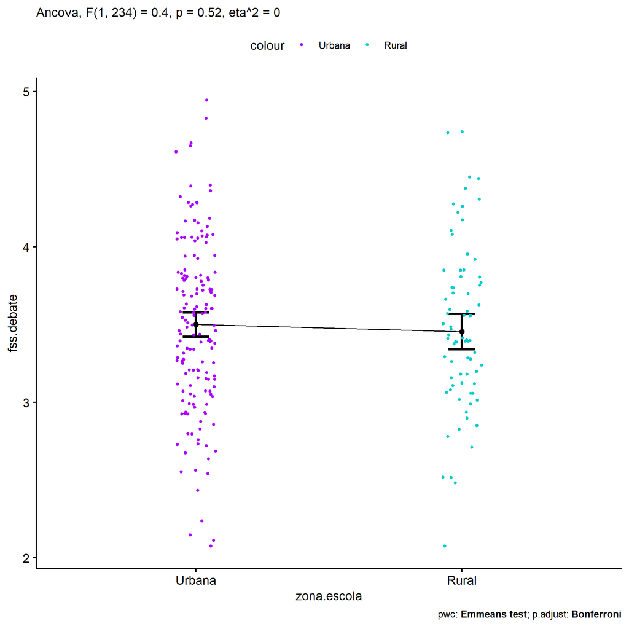

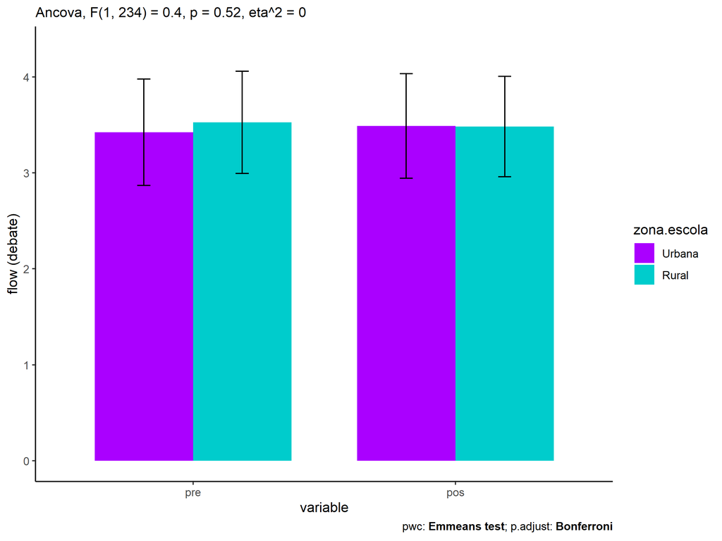

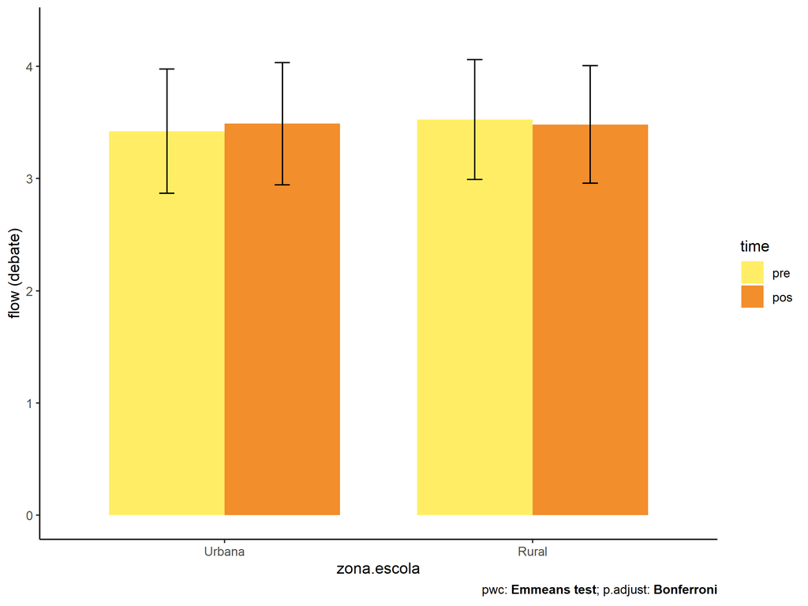